# pdbPlot

Raghav Chanchani

10/24/2018

## References

1. Grant, B.J. et al. (2006) Bioinformatics 22, 2695–2696. Skjaerven, L. et al. (2014) BMC Bioinformatics 15, 399.

## Description

This program reads in a PDB file (given its filename) after downloading it from the internet if it has not been downloaded already. Then, atoms from the chain of interest are checked for beta factor. The beta factors are plotted against the different residues in the file as a line plot with chain shown as bars on the top and bottom of the plot, with user-specified color, if plot argument = TRUE, and if bar argument = TRUE.

1. x - character - a PDB file of interest
2. chain - character - the chain of interest within the structure. Default “A” chain.
3. elety - character - a character vector of atom names you want to extract from chain. Default “CA”, central carbon.
4. plot - logical - whether or not a plot is created
5. bar - logical - whether or not to include secondary structure annotation for chain

### Output

A line plot of the beta factor versus residues with bars showing chains if the “bars = TRUE” and “plot = TRUE” parameters are set.

### Requirements

1. bio3d library (1)

### Function

```r
# loads the bio3d library to use read.pdb, plotb3
library(bio3d)
```

```r
## Description: Reads a PDB file and from the chain and atom of interest,
##              extracts the beta factor and plots against residue if plot is
##              required.
## Usage: Provide PDB file of interest, the chain and atoms of interest, if plot is created (optional),
##        color of plot (optional), and whether or not bar graph of chain is included with line plot (optional)
##        Beta factor extracted from specified secondary structure and plotted (optional) against residues.
## Inputs: x - character - a PDB file of interest
##         chain - character - the chain of interest within the structure - default chain A
##         elety - character - a character vector of atom names you want to extract from chain;
##                            default "CA" central carbon.
##         plot - logical - whether or not a plot is generated
##         bar - logical - whether or not the bars representing chains are shown in the plot
##         col - character - color of the line plot
## Ouput: a line plot of the beta factor versus residues, if user selects TRUE for plot argument
pdb.plot <- function(x, chain = "A", elety = "CA", plot = FALSE, bar = TRUE, col = "black") {
  # read in pdb file; gives warning if file is already downloaded
  s <- read.pdb(x)

  # extract subset of atoms in a PDB file on the desired chain
  s.chain <- trim.pdb(s, chain = chain, elety = elety)

  # extract bata factor from the chain of interest
  s.b <- s.chain$atom$b

  # plot the beta factor versus the residue in a line plot with specified (optional) color
  if(plot) {

    # user specifies inclusion of secondary structure (chain) annotation
    if (bar) {
      return(plotb3(s.b, sse = s.chain, typ = "l", ylab = "Beta Factor", col = col,
                    main = "Residues vs. Beta Factor"))
    }

    # (default) removal of bar plot of secondary structure (chain) annotation
    else {
      return(plotb3(s.b, typ = "l", ylab = "Beta Factor", col = col,
                    main = "Residues vs. Beta Factor"))
    }
  }
}
```

### Example

Accessing the “4AKE” PDB file…

```
##   Note: Accessing on-line PDB file
```

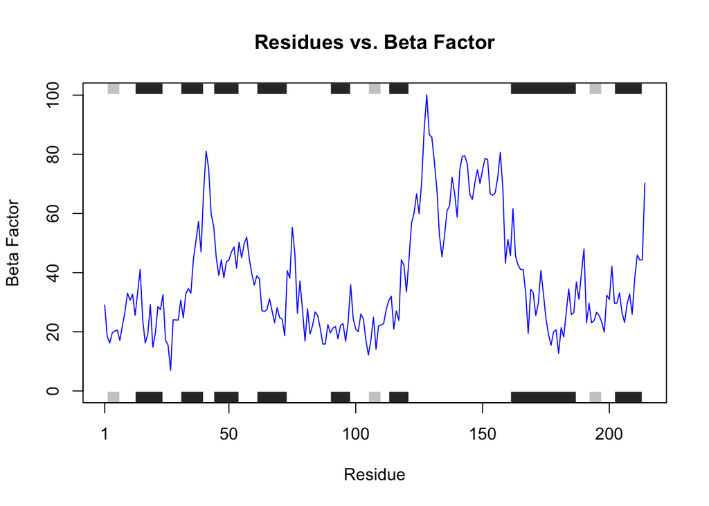

```r
pdb.plot("4AKE", plot = TRUE, bar = TRUE, col = "blue")
```